# Advanced Data Science for Public Policy Final Project

Author

Yi Dou & Yuyan He

# Background

American health insurance is a complicated system. Even within Medicare, beneficiaries may be enrolled in traditional fee-for-service Medicare, Medicare Advantage, Part D prescription coverage, supplemental private plans, or dual Medicare-Medicaid coverage. These forms of enrollment are not randomly distributed across the population; they are often associated with differences in income, health burden, functional limitations, and care needs, which may in turn shape patients’ health care behavior.

In this project, we want to examine whether different Medicare enrollment types appear to emphasize different beneficiary profiles and whether those differences are associated with variation in patient experience and care-seeking behavior. More specifically, we aim to explore two related questions. First, do different types of Medicare coverage tend to concentrate different groups of beneficiaries, in terms of demographic, socioeconomic, and health-status characteristics. Second, whether enrollment types are related to how beneficiaries are served, with particular focus on the delayed care due to cost.

By comparing enrollee profiles and analyzing care-seeking outcomes, we can reveal whether medical resources and insurance arrangements are aligned with patients’ needs.

# Data and Methodology

To address these questions, we focus on the 2023 Medicare Current Beneficiary Survey (MCBS) Public Use File, Fall segment. This file is the latest of the MCBS datasets, which provides a large cross-sectional sample of 13,016 respondents and includes the core enrollment, demographic, health, and access variables needed for the proposed analysis. We limit the study to a single year because the MCBS public-use identifier does not allow linking beneficiaries across years. In addition, CMS explains that the public-use survey data are released in Fall, Winter, and Summer segments, and that the Winter and Summer samples are subsets of the Fall sample, making the Fall file the strongest single analytic base for this study.

This study combines both unsupervised and supervised machine learning approaches.

We first applied latent class analysis (LCA) as an unsupervised learning method to cluster beneficiaries into underlying subgroups based on their demographic, socioeconomic, and health-related characteristics. LCA was selected because the MCBS Fall 2023 data are composed largely of categorical variables, making model-based clustering more appropriate than distance-based methods such as k-means. Candidate models with different numbers of classes were estimated and compared using the Bayesian Information Criterion (BIC), and the final class solution was chosen by balancing model performance and policy interpretability.

After identifying the latent classes, we profiled each class by enrollment type, poverty status, dual-eligibility, health burden, and other relevant characteristics in order to assess whether plan types were concentrated in different target populations.

We then used the delayed-care outcome as the dependent variable in the supervised learning stage. Specifically, we estimated a series of predictive models, including a regression tree, a random forest, a XGBoost, and a stacked ensemble model, to compare predictive performance and identify the variables most strongly associated with delayed care.

# LCA Clustering

## 1.LCA variable and number of class choosing

Since the MCBS dataset consists of categorical variables exclusively, neither PCA or variable correlation - as the typical methods of dimension reducing - is able to help in the variable selection step. We then decided to select variables per the goal of LCA: the unsupervised clustering is meant to investigate whether different enrollment types appear to serve different target populations. Therefore the class-defining variables should mostly capture who the beneficiary is and what level of need/vulnerability they bring. As for the downstream outcomes or behavior related variables such as delayed care, number of doctor visits, falls, preventive-care variables, and the enrollment itself should be removed from the LCA process. Some of the outcomes should be checked after the classes are formed though.

Following the logic, we eventually choose variables that describe baseline demographic, socioeconomic, coverage, and health-related characteristics with arbitrary judgement: age, race/ethnicity, education, poverty status, metro residence, dual-eligibility, low-income subsidy, private supplemental coverage, self-rated health, functional limitation, selected chronic conditions, and household size. In the MCBS Fall 2023 file, these variables are represented by `DEM_AGE`, `DEM_RACE`, `DEM_EDU`, `DEM_IPR_IND`, `DEM_CBSA`, `ADM_OP_MDCD`, `ADM_LIS_FLAG_YR`, `INS_D_PRIVNUMC`, `HLT_GENHELTH`, `HLT_FUNC_LIM`, `HLT_OCBETES`, `HLT_OCDEPRSS`, `HLT_OCEMPHYS`, and `HOU_D_HHTOT`. Outcome variables are also included in the initial raw data for the later profiling process.

In terms of choosing the number of class, prior health-services applications provided a useful benchmark. In a study about segment older adult populations with complex care needs, Bayliss et al. explicitly compared multiple latent class solutions from 1 to 10 classes and selected the final model of 8 class based on fit and interpretability, while McCarthy et al. ultimately identified 4 distinct social-risk groups in their Medicaid cohort. Together, these studies suggest that a middle range of class counts is reasonable in applied healthcare segmentation, while also underscoring that the final choice should balance stability, class size, and interpretability. On that basis, we evaluated models with 4 to 8 classes as a candidate range.

We use poLCA package to do the estimate. Since there is no built weighting function in this package, weights is omitted from the process.

## 2.LCA data cleaning

```r
#install.packages("poLCA")
library(tidyverse)
library(poLCA)

# load data, choose representative variables from each relevant category
data <- read_csv("sfpuf2023_1_fall.csv")

lca_raw <- data |>
  dplyr::select(
    DEM_AGE, DEM_RACE, DEM_EDU, DEM_IPR_IND, DEM_CBSA,
    ADM_OP_MDCD, ADM_LIS_FLAG_YR, INS_D_PRIVNUMC,
    HLT_GENHELTH, HLT_FUNC_LIM, HLT_OCBETES, HLT_OCDEPRSS, HLT_OCEMPHYS,
    HOU_D_HHTOT,
    ADM_MA_FLAG_YR, ADM_FFS_FLAG_YR,
    ACC_HCDELAY
  ) |>
  mutate(across(everything(), as.character)) |>
  mutate(
    across(
      everything(),
      ~ case_when(
        .x %in% c("D", "R", "NA", ".") ~ NA_character_,
        TRUE ~ .x
      )
    )
  )

# Include only full-year enrolled observations to ensure continuous enrollment for better representativeness
lca_raw <- lca_raw |>
  mutate(
    plan_type = case_when(
      ADM_MA_FLAG_YR == 3 ~ "MA",
      ADM_FFS_FLAG_YR == 3 ~ "FFS",
      TRUE ~ NA_character_)) |>
  filter(!is.na(plan_type))

#EDA

## plan type & poverty (1 being below poverty threshold, 5 being the richest)
lca_raw |>
  count(plan_type, DEM_IPR_IND) |>
  group_by(plan_type) |>
  mutate(pct = n / sum(n))
```

```
# A tibble: 10 × 4
# Groups:   plan_type [2]
   plan_type DEM_IPR_IND     n    pct
   <chr>     <chr>       <int>  <dbl>
 1 FFS       1             718 0.125
 2 FFS       2             213 0.0370
 3 FFS       3             206 0.0358
 4 FFS       4             713 0.124
 5 FFS       5            3909 0.679
 6 MA        1            1476 0.222
 7 MA        2             436 0.0655
 8 MA        3             487 0.0731
 9 MA        4            1190 0.179
10 MA        5            3071 0.461
```

```r
## plan type & function limitation (0 with no limitation, 4 with the most limitations)
lca_raw |>
  count(plan_type, HLT_FUNC_LIM) |>
  group_by(plan_type) |>
  mutate(pct = n / sum(n))
```

```
# A tibble: 10 × 4
# Groups:   plan_type [2]
   plan_type HLT_FUNC_LIM     n    pct
   <chr>     <chr>        <int>  <dbl>
 1 FFS       0             3363 0.584
 2 FFS       1              863 0.150
 3 FFS       2              996 0.173
 4 FFS       3              327 0.0568
 5 FFS       4              210 0.0365
 6 MA        0             3583 0.538
 7 MA        1             1055 0.158
 8 MA        2             1297 0.195
 9 MA        3              467 0.0701
10 MA        4              258 0.0387
```

```r
## plan type & self reported health status (1 being excellent, 5 being poor)
lca_raw |>
  count(plan_type, HLT_GENHELTH) |>
  group_by(plan_type) |>
  mutate(pct = n / sum(n))
```

```
# A tibble: 12 × 4
# Groups:   plan_type [2]
   plan_type HLT_GENHELTH     n     pct
   <chr>     <chr>        <int>   <dbl>
 1 FFS       1             1081 0.188
 2 FFS       2             1970 0.342
 3 FFS       3             1667 0.289
 4 FFS       4              760 0.132
 5 FFS       5              266 0.0462
 6 FFS       <NA>            15 0.00260
 7 MA        1              956 0.144
 8 MA        2             2066 0.310
 9 MA        3             2054 0.308
10 MA        4             1211 0.182
11 MA        5              356 0.0535
12 MA        <NA>            17 0.00255
```

Because of the very simple data structure, we did not do a comprehensive EDA section. However from the results, we can still see the variables appear to retain usable variation for later modeling. In addition, Medicare Advantage enrollees seem to be disproportionately lower-income people, and slightly more likely to report poorer health and greater functional limitation than traditional fee-for-service beneficiaries. Note that these are only unadjusted descriptive patterns and should not be interpreted causally, since they may reflect beneficiary sorting into plans rather than the effect of plan design itself.

```r
# data refining

## Combine subcategories of only a few observations into a broader subcategory to reduce noise
lca_raw <- lca_raw |>
  mutate(
    dual_lca = case_when(
      ADM_OP_MDCD == 1 ~ "Nondual",
      ADM_OP_MDCD %in% c(2, 3, 4) ~ "Dual",
      TRUE ~ NA_character_),
    lis_lca = case_when(
      ADM_LIS_FLAG_YR == 1 ~ "No subsidy",
      ADM_LIS_FLAG_YR %in% c(2, 3) ~ "Any subsidy",
      TRUE ~ NA_character_),
    priv_lca = case_when(
      INS_D_PRIVNUMC == 0 ~ "No private plan",
      INS_D_PRIVNUMC == 1 ~ "One private plan",
      INS_D_PRIVNUMC %in% c(2, 3) ~ "Two+ private plans",
      TRUE ~ NA_character_),
    hhsize_lca = case_when(
      HOU_D_HHTOT == 1 ~ "1 person",
      HOU_D_HHTOT == 2 ~ "2 people",
      HOU_D_HHTOT >= 3 ~ "3+ people",
      TRUE ~ NA_character_)
  )

##  change values to integers for LCA preparation
lca_data <- lca_raw |>
  mutate(
    DEM_AGE = as.integer(factor(DEM_AGE)),
    DEM_RACE = as.integer(factor(DEM_RACE)),
    DEM_EDU = as.integer(factor(DEM_EDU)),
    DEM_IPR_IND = as.integer(factor(DEM_IPR_IND)),
    DEM_CBSA = as.integer(factor(DEM_CBSA)),
    dual_lca = as.integer(factor(dual_lca)),
    lis_lca = as.integer(factor(lis_lca)),
    priv_lca = as.integer(factor(priv_lca)),
    HLT_GENHELTH = as.integer(factor(HLT_GENHELTH)),
    HLT_FUNC_LIM = as.integer(factor(HLT_FUNC_LIM)),
    HLT_OCBETES = as.integer(factor(HLT_OCBETES)),
    HLT_OCDEPRSS = as.integer(factor(HLT_OCDEPRSS)),
    HLT_OCEMPHYS = as.integer(factor(HLT_OCEMPHYS)),
    hhsize_lca = as.integer(factor(hhsize_lca))
  ) |>
## include only the manifest variables
  dplyr::select(
    DEM_AGE, DEM_RACE, DEM_EDU, DEM_IPR_IND, DEM_CBSA,
    dual_lca, lis_lca, priv_lca,
    HLT_GENHELTH, HLT_FUNC_LIM, HLT_OCBETES, HLT_OCDEPRSS, HLT_OCEMPHYS,
    hhsize_lca,
    ADM_MA_FLAG_YR, ADM_FFS_FLAG_YR, ACC_HCDELAY
  )
```

In order to find the global maximum, for each candidate class solution, we used multiple random starts and inspected the log-likelihood values across attempts. Following poLCA package CRAN guidance, we started from nrep = 10 and increased the number until the highest log-likelihood was stably recovered, and we set the maximum number of iterations high enough to avoid premature stopping of the estimation algorithm.

## 3.LCA modeling

```r
# Define the LCA formula
f_lca <- cbind(
  DEM_AGE, DEM_RACE, DEM_EDU, DEM_IPR_IND, DEM_CBSA,
  dual_lca, lis_lca, priv_lca,
  HLT_GENHELTH, HLT_FUNC_LIM, HLT_OCBETES, HLT_OCDEPRSS, HLT_OCEMPHYS,
  hhsize_lca
) ~ 1

# check class from 4 to 8
set.seed(123)

lca_4 <- poLCA(f_lca, data = lca_data, nclass = 4, nrep = 20,
               maxiter = 3000, na.rm = FALSE, verbose = FALSE)

lca_5 <- poLCA(f_lca, data = lca_data, nclass = 5, nrep = 20,
               maxiter = 3000, na.rm = FALSE, verbose = FALSE)

lca_6 <- poLCA(f_lca, data = lca_data, nclass = 6, nrep = 50,
               maxiter = 3000, na.rm = FALSE, verbose = FALSE)

lca_7 <- poLCA(f_lca, data = lca_data, nclass = 7, nrep = 50,
               maxiter = 3000, na.rm = FALSE, verbose = FALSE)

lca_8 <- poLCA(f_lca, data = lca_data, nclass = 8, nrep = 20,
               maxiter = 3000, na.rm = FALSE, verbose = FALSE)

# Check statistics for each class
lca_4$llik
```

```
[1] -132011.3
```

```r
lca_4$attempts
```

```
 [1] -132011.3 -132342.2 -132342.2 -132011.3 -132011.3 -132011.3 -132011.3
 [8] -132342.2 -132011.3 -132011.3 -132011.3 -132011.3 -132011.3 -132011.3
[15] -132011.3 -132011.3 -132342.2 -132011.3 -132011.3 -132011.3
```

```r
lca_5$llik
```

```
[1] -131446.5
```

```r
lca_5$attempts
```

```
 [1] -131446.5 -131507.1 -131507.1 -131652.8 -131652.8 -131446.5 -131507.1
 [8] -131446.5 -131507.1 -131446.5 -131446.5 -131446.5 -131652.8 -131507.1
[15] -131652.9 -131507.1 -131652.8 -131885.4 -131446.5 -131507.1
```

```r
lca_6$llik
```

```
[1] -131055.1
```

```r
lca_6$attempts
```

```
 [1] -131154.0 -131407.7 -131154.0 -131089.6 -131408.4 -131055.1 -131407.7
 [8] -131154.0 -131055.1 -131407.7 -131408.4 -131407.7 -131407.7 -131655.6
[15] -131407.7 -131154.0 -131055.1 -131089.6 -131154.0 -131055.1 -131154.0
[22] -131154.0 -131407.7 -131089.6 -131089.6 -131089.6 -131055.1 -131154.0
[29] -131407.7 -131089.6 -131089.6 -131089.6 -131159.1 -131089.6 -131154.0
[36] -131055.1 -131407.7 -131154.0 -131154.0 -131055.1 -131089.6 -131154.0
[43] -131089.6 -131154.0 -131407.7 -131154.0 -131159.1 -131442.2 -131407.7
[50] -131407.7
```

```r
lca_7$llik
```

```
[1] -130702.4
```

```r
lca_7$attempts
```

```
 [1] -130702.4 -130857.4 -130912.0 -130857.4 -130857.4 -130702.4 -130857.4
 [8] -130947.8 -131214.3 -130857.4 -130883.9 -130950.9 -130912.0 -130702.4
[15] -130884.0 -130912.0 -130702.4 -130845.3 -130702.4 -130702.4 -131214.3
[22] -130702.4 -130885.6 -130912.0 -130702.4 -130885.6 -130889.8 -130702.4
[29] -131214.3 -130702.4 -130950.9 -130702.4 -130912.0 -130857.4 -130857.4
[36] -130857.4 -130883.9 -130950.9 -130857.4 -130912.0 -130883.9 -130702.4
[43] -130857.4 -130912.0 -130702.4 -130857.4 -130702.4 -130885.6 -130857.4
[50] -130950.9
```

```r
fit_stats <- tibble(
  classes = 4:8,
  BIC = c(lca_4$bic, lca_5$bic, lca_6$bic, lca_7$bic, lca_8$bic),
  logLik = c(lca_4$llik, lca_5$llik, lca_6$llik, lca_7$llik, lca_8$llik)
)

fit_stats
```

```
# A tibble: 5 × 3
  classes     BIC   logLik
    <int>   <dbl>    <dbl>
1       4 265144. -132011.
2       5 264298. -131446.
3       6 263798. -131055.
4       7 263375. -130702.
5       8 263190. -130468.
```

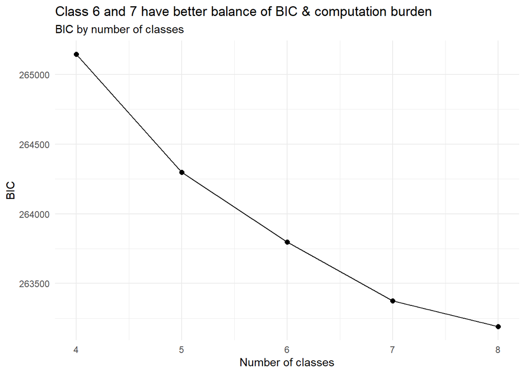

```r
fit_stats |>
  ggplot(aes(x = classes, y = BIC)) +
  geom_line() +
  geom_point(size = 2) +
  scale_x_continuous(breaks = 4:8) +
  labs(
    x = "Number of classes",
    y = "BIC",
    title = "Class 6 and 7 have better balance of BIC & computation burden",
    subtitle = "BIC by number of classes"
  ) +
  theme_minimal()
```

## 4.LCA results, profiling and discussion

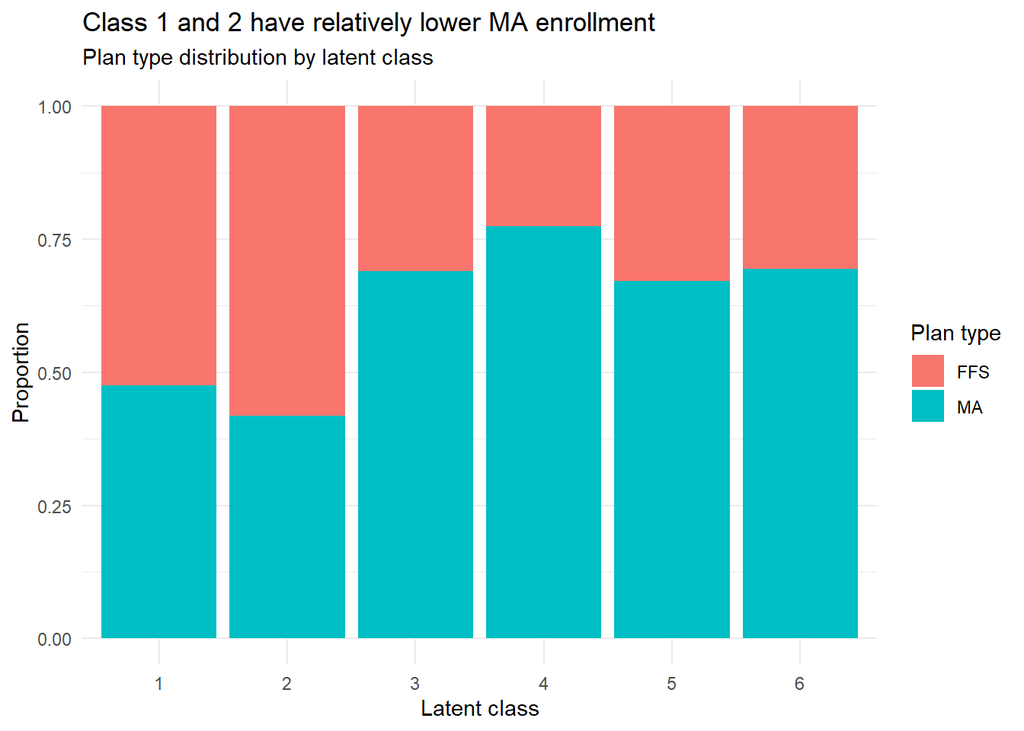

```r
library(gt)

# Get the data with the LCA model of class = 6
profile_data <- lca_raw |>
  mutate(class = factor(lca_6$predclass)) |>
  filter(!is.na(HLT_GENHELTH)) |>
    mutate(
    age_label = case_when(
      DEM_AGE == "1" ~ "<65",
      DEM_AGE == "2" ~ "65-74",
      DEM_AGE == "3" ~ "75+"
    ),
    health_label = case_when(
      HLT_GENHELTH == "1" ~ "Excellent",
      HLT_GENHELTH == "2" ~ "Very good",
      HLT_GENHELTH == "3" ~ "Good",
      HLT_GENHELTH == "4" ~ "Fair",
      HLT_GENHELTH == "5" ~ "Poor",
    ),
    poverty_label = case_when(
      DEM_IPR_IND == "1" ~ "<=100% FPL",
      DEM_IPR_IND == "2" ~ ">100%-120% FPL",
      DEM_IPR_IND == "3" ~ ">120%-135% FPL",
      DEM_IPR_IND == "4" ~ ">135%-200% FPL",
      DEM_IPR_IND == "5" ~ ">200% FPL",
    ),
    health_label = factor(health_label, levels = c("Excellent", "Very good", "Good", "Fair", "Poor")))


# Visualization for plan type within classes
profile_data |>
  count(class, plan_type) |>
  group_by(class) |>
  mutate(pct = n / sum(n)) |>
  ggplot(aes(x = class, y = pct, fill = plan_type)) +
  geom_col() +
  labs(
    x = "Latent class",
    y = "Proportion",
    fill = "Plan type",
    title = "Class 1 and 2 have relatively lower MA enrollment",
    subtitle = "Plan type distribution by latent class"
  ) +
  theme_minimal()
```

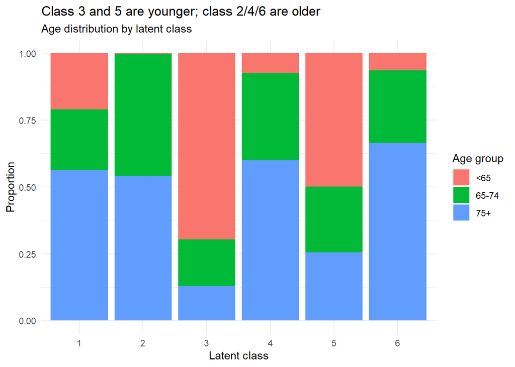

```r
# Visualization for age within classes
profile_data |>
  count(class, age_label) |>
  group_by(class) |>
  mutate(pct = n / sum(n)) |>
  ggplot(aes(x = class, y = pct, fill = factor(age_label))) +
  geom_col() +
  labs(
    x = "Latent class",
    y = "Proportion",
    fill = "Age group",
    title = "Class 3 and 5 are younger; class 2/4/6 are older",
    subtitle = "Age distribution by latent class"
  ) +
  theme_minimal()
```

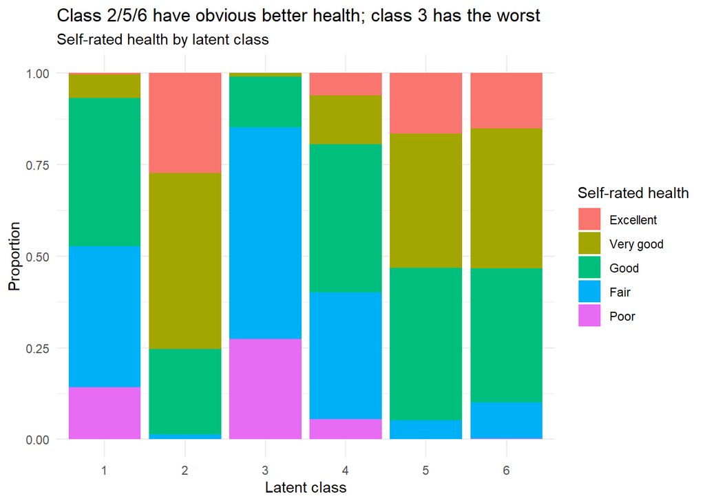

```r
# Visualization for self report health status within classes
profile_data |>
  count(class, health_label) |>
  group_by(class) |>
  mutate(pct = n / sum(n)) |>
  ggplot(aes(x = class, y = pct, fill = factor(health_label))) +
  geom_col() +
  labs(
    x = "Latent class",
    y = "Proportion",
    fill = "Self-rated health",
    title = "Class 2/5/6 have obvious better health; class 3 has the worst",
    subtitle = "Self-rated health by latent class"
  ) +
  theme_minimal()
```

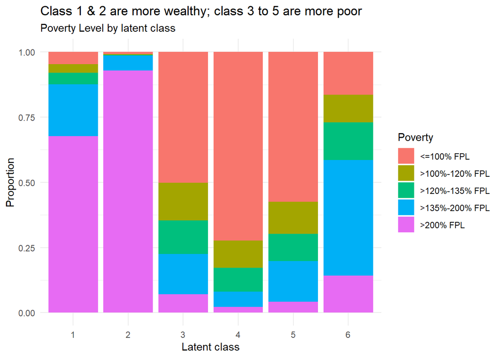

```r
# Visualization for poverty level within classes
profile_data |>
  count(class, poverty_label) |>
  group_by(class) |>
  mutate(pct = n / sum(n)) |>
  ggplot(aes(x = class, y = pct, fill = factor(poverty_label))) +
  geom_col() +
  labs(
    x = "Latent class",
    y = "Proportion",
    fill = "Poverty",
    title = "Class 1 & 2 are more wealthy; class 3 to 5 are more poor",
    subtitle = "Poverty Level by latent class"
  ) +
  theme_minimal()
```

```r
# summarize relevant profile information across classes
profile_data |>
  group_by(class) |>
  summarise(
    n = n(),
    pct_MA = mean(plan_type == "MA", na.rm = TRUE),
    pct_age75plus = mean(DEM_AGE == 3, na.rm = TRUE),
    pct_poor = mean(DEM_IPR_IND == 1, na.rm = TRUE),
    pct_dual = mean(dual_lca == "Dual", na.rm = TRUE),
    pct_fairpoor_health = mean(HLT_GENHELTH %in% c(4, 5), na.rm = TRUE),
    pct_depression = mean(HLT_OCDEPRSS == 1, na.rm = TRUE),
    pct_function_limit = mean(HLT_FUNC_LIM %in% c(1, 2, 3, 4), na.rm = TRUE),
    pct_delay = mean(ACC_HCDELAY == 1, na.rm = TRUE)
  ) |>
  gt()
```

| class | n | pct_MA | pct_age75plus | pct_poor | pct_dual | pct_fairpoor_health | pct_depression | pct_function_limit | pct_delay |
| --- | --- | --- | --- | --- | --- | --- | --- | --- | --- |
| 1 | 2044 | 0.4760274 | 0.5621331 | 0.047455969 | 0.000000000 | 0.52739726 | 0.4761671 | 0.9241683 | 0.10279001 |
| 2 | 5589 | 0.4176060 | 0.5417785 | 0.007693684 | 0.000000000 | 0.01341922 | 0.1420129 | 0.1674718 | 0.02576951 |
| 3 | 1038 | 0.6907514 | 0.1300578 | 0.501926782 | 0.919075145 | 0.85163776 | 0.7011605 | 0.8795761 | 0.14478764 |
| 4 | 791 | 0.7749684 | 0.5992415 | 0.723135272 | 0.946902655 | 0.40075853 | 0.3244613 | 0.6245259 | 0.05316456 |
| 5 | 1158 | 0.6718480 | 0.2556131 | 0.575129534 | 0.970639033 | 0.05181347 | 0.2491349 | 0.5138169 | 0.06655143 |
| 6 | 1767 | 0.6949632 | 0.6649689 | 0.164685908 | 0.000565931 | 0.10130164 | 0.1205433 | 0.3537068 | 0.06172140 |

By comparing each cluster’s plan enrollment and demographic profile, the 6 classes could be profiled as follows:

Class 1: Mixed enrollment, not poor, non-dual, high-need group

This class is not MA-heavy: about 48% are in MA, so it is the most balanced class and relatively more FFS-oriented than most others. At the same time, it is almost entirely non-dual and not especially poor, but it stands out for very high functional limitation (92%), and with relatively high fair/poor health (53%) and high level of depression (48%) compared. It’s the class with the second highest delay care proportion.

Class 2: Slightly FFS-leaning, healthy and economically secure mainstream group, low-need

This class has only about 42% in MA, making it the most FFS-leaning class in the sample. It is overwhelmingly non-poor, entirely non-dual, and clearly the healthiest class, with the lowest levels of fair/poor health, very low depression, and the lowest functional limitation. This group also has the lowest delay care share.

Class 3: MA-dominant, severely vulnerable, youngest, poor, dual-eligible, highest-need group

Class 4: MA-dominant, older, poor, dual-eligible, moderate-need group

This class is strongly Medicare Advantage-oriented: about 77% are in MA, the highest MA share among all classes. It is also heavily poor (72%) and overwhelmingly dual-eligible (95%), with a relatively old age structure (60% age 75+). In health terms, this class has moderate to high need, with moderate to high levels of fair/poor health, depression, and functional limitation. With no obvious sign of delayed care.

Class 5: MA-dominant, younger, poor, dual-eligible group with moderate need

This class is also clearly MA-dominant, with about 67% in MA. It is quite poor (58%) and overwhelmingly dual-eligible (97%), but it is noticeably younger (only 26% age 75+). Its health burden appears moderate: functional limitation is moderate, but fair/poor self-rated health is relatively low. Delay of care is also not obvious in the class.

Class 6: MA-dominant, not poor, non-dual group, older but quite healthy

This class is again MA-heavy, with roughly 69% in MA. Unlike Classes 3 to 5, however, it is almost entirely non-dual, not especially poor, and relatively healthy, with low fair/poor health, low depression, and only moderate functional limitation. It is also the oldest classes (67% age 75+). Similarly, delay of care is not obvious in the class.

Discussion:

We can see that each class has its own unique characters, which indicates good LCA results. The highly consistency between poverty and dual-eligibility also indicates good data quality. While the percentage of each class is meaningful to be estimated, we omitted this step as the data are not weighted to represent the general population.

While traditional FFS Medicare plan is slightly leaning towards a wealthier class, MA mostly dominates the other classes, of which their enrollees don’t really have consistent pattern regarding socioeconomic, demographic, or health profile. This might suggest that, MA does not seem to address any specific needs of specific subpopulation.

Meanwhile, the delay of care does not seem to be correlated with plan enrollment, but seems to be driven mostly by poverty and high needs. This result might suggest that MA does not address its initial purpose when launching, which is to improve health equity for the disadvantaged, and manage chronic conditions more effectively. This result also helps build foundation for variable choosing in the later predictive modeling phase.

Due to the rough granularity of this dataset, we can’t really decide whether MA improves healthcare quality for certain groups at all. But it seems clear that MA does not really associated to any specific subgroup, which might mean flexibility, or maybe simply suggest its lack of obvious advantage compared to traditional Medicare plan.

# Predictive Model

## 1. Setup and Data Loading

```r
library(tidymodels)
library(tidyverse)
library(stacks)
library(xgboost)
library(themis)
library(probably)
library(vip)
library(here)

set.seed(42)
```

```r
data <- read_csv(here("sfpuf2023_1_fall.csv"))
```

## 2. Data Preprocessing

Replace “R” (refused) and “D” (don’t know) responses with NA, convert all predictors to factors, and remove administrative variables.

```r
df <- data |>
  select(-PUF_ID, -SURVEYYR, -VERSION, -PUFFWGT, -starts_with("PUFF")) |>
  select(-DEM_RE_AGE) |>
  mutate(across(everything(), ~ if_else(. %in% c("R", "D"), NA_character_, as.character(.)))) |>
  filter(!is.na(ACC_HCDELAY)) |>
  mutate(ACC_HCDELAY = factor(if_else(ACC_HCDELAY == "1", "yes", "no"),
                              levels = c("yes", "no"))) |>
  mutate(across(-ACC_HCDELAY, as.factor))

cat("Outcome distribution:\n")
```

```
Outcome distribution:
```

```r
print(table(df$ACC_HCDELAY))
```

```
  yes    no
  821 12185
```

```r
cat("Total sample size:", nrow(df), "\n")
```

```
Total sample size: 13006
```

## 3. Train/Test Split

Use stratified 80/20 split to preserve the outcome class ratio.

```r
split <- initial_split(df, prop = 0.8, strata = ACC_HCDELAY)
train <- training(split)
test  <- testing(split)

cat("Training set:", nrow(train), "  Test set:", nrow(test), "\n")
```

```
Training set: 10404   Test set: 2602
```

## 4. Variable Screening

To avoid manual variable selection, we use a split-sample approach: a 30% screening subset is held out from the training data for a preliminary Random Forest that ranks all available predictors by impurity-based importance. The top 25 variables are then carried forward into formal modeling on the remaining 70%. This ensures the screening step does not use the same data as model training and evaluation.

```r
screen_split <- initial_split(train, prop = 0.3, strata = ACC_HCDELAY)
screen_data  <- training(screen_split)
model_data   <- testing(screen_split)

# Fit a quick RF directly with ranger to handle factors without dummy encoding
screen_rf <- ranger::ranger(
  ACC_HCDELAY ~ .,
  data = screen_data,
  num.trees = 300,
  importance = "impurity"
)

# Extract top 25 variables by importance
top_vars <- names(sort(screen_rf$variable.importance, decreasing = TRUE))[1:25]

cat("Top 25 selected variables:\n")
```

```
Top 25 selected variables:
```

```r
print(top_vars)
```

```
 [1] "ACC_PAYPROB"  "ACC_PAYOVRTM" "ACC_MCCOSTS"  "HLT_TOOTHSEN" "ACC_HCTROUBL"
 [6] "HLT_FOODTRBL" "ACC_HCTRBMNY" "HOU_NBRROOMS" "HLT_TEETHGUM" "HLT_DRYMOUTH"
[11] "ACC_MCQUALTY" "HLT_D_MODTIM" "ACC_MCEASE"   "HLT_HYPELONG" "HLT_EDOCLAST"
[16] "FAL_FALLFEAR" "PRV_BCTAKEN"  "ACC_MCSPECAR" "HLT_D_MUSTIM" "HLT_GENHELTH"
[21] "HLT_COMPHLTH" "ACC_MCCONCRN" "ACC_MCAVAIL"  "HOU_D_HHTOT"  "DEM_IPR_IND"
```

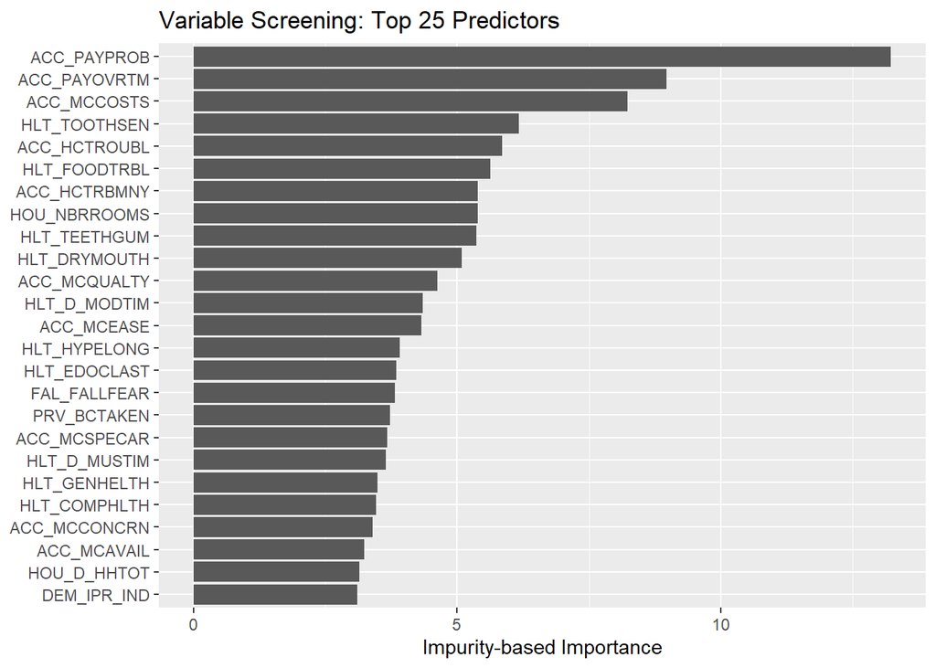

```r
# Visualize screening results
tibble(
  variable   = names(screen_rf$variable.importance),
  importance = screen_rf$variable.importance
) |>
  slice_max(importance, n = 25) |>
  mutate(variable = fct_reorder(variable, importance)) |>
  ggplot(aes(x = importance, y = variable)) +
  geom_col() +
  labs(title = "Variable Screening: Top 25 Predictors",
       x = "Impurity-based Importance", y = NULL)
```

The variable importance ranking reveals that the strongest predictors of delayed care due to cost are not demographic or clinical characteristics, but rather variables capturing the beneficiary’s lived experience of navigating the health care system — especially financial strain and subjective assessments of care quality. The top three predictors (ACC_PAYPROB, ACC_PAYOVRTM, ACC_MCCOSTS) all relate directly to medical bill burden, suggesting that cost-related access barriers are most powerfully predicted by other dimensions of financial difficulty rather than by income or insurance type alone. By contrast, traditional demographic variables (age, sex, race) and specific chronic disease indicators — which are often foregrounded in health policy research — did not rank among the top 25, suggesting that experiential and functional measures may carry more predictive signal for access-related outcomes than standard clinical or demographic profiles.

```r
# Subset model_data to selected variables for formal modeling
model_data <- model_data |>
  select(ACC_HCDELAY, all_of(top_vars))

# Create CV folds on the modeling subset
folds <- vfold_cv(model_data, v = 5, strata = ACC_HCDELAY)

cat("Modeling subset size:", nrow(model_data), "\n")
```

```
Modeling subset size: 7283
```

## 5. Recipe

Preprocessing pipeline: drop high-missingness variables (>80%), remove near-zero-variance predictors, impute remaining missing values with mode, create dummy variables, and upsample the minority class to full balance. We did not apply survey weights in the modeling pipeline because we want to keep consistent with the LCA clustering workflow, and also because our objective is predictive performance rather than population-level inference, while survey weights are designed to produce unbiased estimates of population parameters, which is a different goal from optimizing out-of-sample prediction accuracy.

```r
base_recipe <- recipe(ACC_HCDELAY ~ ., data = model_data) |>
  step_filter_missing(all_predictors(), threshold = 0.8) |>
  step_nzv(all_predictors()) |>
  step_impute_mode(all_nominal_predictors()) |>
  step_dummy(all_nominal_predictors(), one_hot = FALSE) |>
  step_upsample(ACC_HCDELAY, over_ratio = 1)
```

## 6. Model Training

Shared tuning control: save out-of-fold predictions and workflows for stacking.

```r
ctrl <- control_grid(save_pred = TRUE, save_workflow = TRUE)
```

### 6a. Decision Tree

```r
tree_spec <- decision_tree(
  cost_complexity = tune(),
  tree_depth = tune()
) |>
  set_engine("rpart") |>
  set_mode("classification")

tree_wf <- workflow() |> add_recipe(base_recipe) |> add_model(tree_spec)

tree_grid <- grid_regular(
  cost_complexity(),
  tree_depth(range = c(3, 10)),
  levels = 5
)

tree_res <- tune_grid(tree_wf, resamples = folds, grid = tree_grid, control = ctrl)

cat("Decision Tree complete. Best CV AUC:",
    show_best(tree_res, metric = "roc_auc", n = 1)$mean, "\n")
```

```
Decision Tree complete. Best CV AUC: 0.7486188
```

### 6b. Random Forest

```r
rf_spec <- rand_forest(
  mtry = tune(),
  trees = 500,
  min_n = tune()
) |>
  set_engine("ranger") |>
  set_mode("classification")

rf_wf <- workflow() |> add_recipe(base_recipe) |> add_model(rf_spec)

rf_grid <- grid_regular(
  mtry(range = c(5, 30)),
  min_n(range = c(5, 20)),
  levels = 4
)

rf_res <- tune_grid(rf_wf, resamples = folds, grid = rf_grid, control = ctrl)

cat("Random Forest complete. Best CV AUC:",
    show_best(rf_res, metric = "roc_auc", n = 1)$mean, "\n")
```

```
Random Forest complete. Best CV AUC: 0.8340129
```

### 6c. XGBoost

XGBoost uses a separate recipe without upsampling; class imbalance is handled via `scale_pos_weight` in the engine, which avoids the instability observed when combining `step_upsample` with boosted trees during refitting.

```r
xgb_recipe <- recipe(ACC_HCDELAY ~ ., data = model_data) |>
  step_filter_missing(all_predictors(), threshold = 0.8) |>
  step_nzv(all_predictors()) |>
  step_impute_mode(all_nominal_predictors()) |>
  step_dummy(all_nominal_predictors(), one_hot = FALSE)

pos_weight <- sum(model_data$ACC_HCDELAY == "no") / sum(model_data$ACC_HCDELAY == "yes")

xgb_spec <- boost_tree(
  trees = tune(),
  tree_depth = tune(),
  learn_rate = tune()
) |>
  set_engine("xgboost", scale_pos_weight = pos_weight) |>
  set_mode("classification")

xgb_wf <- workflow() |> add_recipe(xgb_recipe) |> add_model(xgb_spec)

xgb_grid <- grid_regular(
  trees(range = c(50, 300)),
  tree_depth(range = c(2, 6)),
  learn_rate(range = c(-2, -1)),
  levels = 3
)

xgb_res <- tune_grid(xgb_wf, resamples = folds, grid = xgb_grid, control = ctrl)

cat("XGBoost complete. Best CV AUC:",
    show_best(xgb_res, metric = "roc_auc", n = 1)$mean, "\n")
```

```
XGBoost complete. Best CV AUC: 0.8374841
```

## 7. Stacked Ensemble

Combine the three base learners using a Lasso meta-learner that optimizes AUC to determine blending weights.

```r
stack_model <- stacks() |>
  add_candidates(tree_res) |>
  add_candidates(rf_res) |>
  add_candidates(xgb_res) |>
  blend_predictions(metric = metric_set(roc_auc)) |>
  fit_members()
```

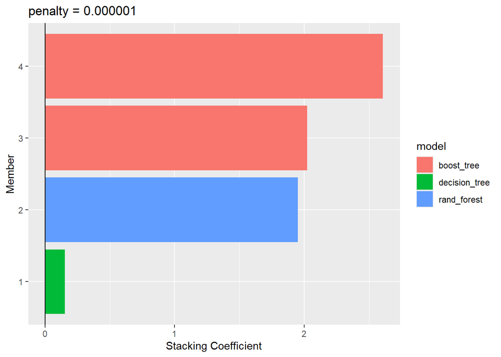

```r
autoplot(stack_model, type = "weights")
```

## 8. Evaluation at Default Threshold (0.5)

```r
best_tree <- tree_res |> fit_best()
best_rf   <- rf_res |> fit_best()
best_xgb  <- xgb_res |> fit_best()

eval_model <- function(model, name) {
  preds <- predict(model, test, type = "prob") |>
    bind_cols(predict(model, test)) |>
    bind_cols(test |> select(ACC_HCDELAY))

  tibble(
    model     = name,
    auc       = roc_auc(preds, ACC_HCDELAY, .pred_yes)$.estimate,
    recall    = recall(preds, ACC_HCDELAY, .pred_class)$.estimate,
    precision = precision(preds, ACC_HCDELAY, .pred_class)$.estimate,
    f1        = f_meas(preds, ACC_HCDELAY, .pred_class)$.estimate
  )
}

stack_preds <- predict(stack_model, test, type = "prob") |>
  bind_cols(predict(stack_model, test)) |>
  bind_cols(test |> select(ACC_HCDELAY))

results <- bind_rows(
  eval_model(best_tree, "Decision Tree"),
  eval_model(best_rf, "Random Forest"),
  eval_model(best_xgb, "XGBoost"),
  tibble(
    model     = "Stacked Ensemble",
    auc       = roc_auc(stack_preds, ACC_HCDELAY, .pred_yes)$.estimate,
    recall    = recall(stack_preds, ACC_HCDELAY, .pred_class)$.estimate,
    precision = precision(stack_preds, ACC_HCDELAY, .pred_class)$.estimate,
    f1        = f_meas(stack_preds, ACC_HCDELAY, .pred_class)$.estimate
  )
)

cat("Model comparison at default threshold (0.5):\n")
```

```
Model comparison at default threshold (0.5):
```

```r
print(results)
```

```
# A tibble: 4 × 5
  model              auc recall precision    f1
  <chr>            <dbl>  <dbl>     <dbl> <dbl>
1 Decision Tree    0.715  0.635     0.188 0.289
2 Random Forest    0.834  0.237     0.649 0.347
3 XGBoost          0.851  0.679     0.249 0.365
4 Stacked Ensemble 0.849  0.167     0.703 0.269
```

## 9. Threshold Tuning

Search for the optimal classification threshold that maximizes F1 score. For Decision Tree, Random Forest, and XGBoost, thresholds are selected on cross-validation out-of-fold predictions to avoid data leakage. For the Stacked Ensemble, the threshold is selected on the test set since CV-level predictions are not available; this may produce a slightly optimistic estimate.

```r
# Function to find optimal threshold from CV out-of-fold predictions
find_best_threshold <- function(tune_res, metric_name = "roc_auc") {
  cv_preds <- tune_res |>
    collect_predictions(parameters = select_best(tune_res, metric = metric_name))

  cv_preds |>
    threshold_perf(ACC_HCDELAY, .pred_yes,
                   thresholds = seq(0.05, 0.95, by = 0.01),
                   metrics = metric_set(f_meas)) |>
    filter(.metric == "f_meas") |>
    slice_max(.estimate, n = 1) |>
    pull(.threshold)
}

# Optimal thresholds for base models (from CV)
tree_thresh <- find_best_threshold(tree_res)
rf_thresh   <- find_best_threshold(rf_res)
xgb_thresh  <- find_best_threshold(xgb_res)

cat("Decision Tree optimal threshold:", tree_thresh, "\n")
```

```
Decision Tree optimal threshold: 0.84
```

```r
cat("Random Forest optimal threshold:", rf_thresh, "\n")
```

```
Random Forest optimal threshold: 0.37
```

```r
cat("XGBoost optimal threshold:",       xgb_thresh, "\n")
```

```
XGBoost optimal threshold: 0.73
```

```r
# Stacked Ensemble threshold (from test set — see caveat above)
stack_thresh_search <- stack_preds |>
  threshold_perf(ACC_HCDELAY, .pred_yes,
                 thresholds = seq(0.05, 0.95, by = 0.01),
                 metrics = metric_set(f_meas)) |>
  filter(.metric == "f_meas") |>
  slice_max(.estimate, n = 1)

stack_thresh <- stack_thresh_search$.threshold
cat("Stacked Ensemble optimal threshold:", stack_thresh, "\n")
```

```
Stacked Ensemble optimal threshold: 0.2
```

## 10. Final Evaluation at Optimal Thresholds

```r
eval_with_threshold <- function(model, name, threshold) {
  preds <- predict(model, test, type = "prob") |>
    bind_cols(test |> dplyr::select(ACC_HCDELAY)) |>
    mutate(.pred_class = factor(if_else(.pred_yes > threshold, "yes", "no"),
                                levels = c("yes", "no")))

  tibble(
    model     = name,
    threshold = threshold,
    auc       = roc_auc(preds, ACC_HCDELAY, .pred_yes)$.estimate,
    recall    = recall(preds, ACC_HCDELAY, .pred_class)$.estimate,
    precision = precision(preds, ACC_HCDELAY, .pred_class)$.estimate,
    f1        = f_meas(preds, ACC_HCDELAY, .pred_class)$.estimate
  )
}

stack_final <- stack_preds |>
  mutate(.pred_class = factor(if_else(.pred_yes > stack_thresh, "yes", "no"),
                              levels = c("yes", "no")))

results_tuned <- bind_rows(
  eval_with_threshold(best_tree, "Decision Tree", tree_thresh),
  eval_with_threshold(best_rf,   "Random Forest", rf_thresh),
  eval_with_threshold(best_xgb,  "XGBoost",       xgb_thresh),
  tibble(
    model     = "Stacked Ensemble",
    threshold = stack_thresh,
    auc       = roc_auc(stack_final, ACC_HCDELAY, .pred_yes)$.estimate,
    recall    = recall(stack_final, ACC_HCDELAY, .pred_class)$.estimate,
    precision = precision(stack_final, ACC_HCDELAY, .pred_class)$.estimate,
    f1        = f_meas(stack_final, ACC_HCDELAY, .pred_class)$.estimate
  )
)

cat("\nDefault threshold (0.5):\n")
```

```
Default threshold (0.5):
```

```r
print(results)
```

```
# A tibble: 4 × 5
  model              auc recall precision    f1
  <chr>            <dbl>  <dbl>     <dbl> <dbl>
1 Decision Tree    0.715  0.635     0.188 0.289
2 Random Forest    0.834  0.237     0.649 0.347
3 XGBoost          0.851  0.679     0.249 0.365
4 Stacked Ensemble 0.849  0.167     0.703 0.269
```

```r
cat("\nOptimal threshold:\n")
```

```
Optimal threshold:
```

```r
print(results_tuned)
```

```
# A tibble: 4 × 6
  model            threshold   auc recall precision    f1
  <chr>                <dbl> <dbl>  <dbl>     <dbl> <dbl>
1 Decision Tree         0.84 0.715  0.359     0.389 0.373
2 Random Forest         0.37 0.834  0.487     0.388 0.432
3 XGBoost               0.73 0.851  0.526     0.414 0.463
4 Stacked Ensemble      0.2  0.849  0.551     0.398 0.462
```

# Conclusion and Limitation

Taken together, the LCA and supervised learning results point to a consistent conclusion: delayed care in this sample is driven much more by beneficiaries’ financial vulnerability and health burden than by enrollment in specific plan type. In this sense, our findings do not provide clear evidence that Medicare Advantage is systematically reaching or better serving a distinct disadvantaged subgroup in a way that reduces delayed care.

This conclusion is important from a policy perspective. Medicare Advantage has often been discussed as a model that could promote more coordinated care, improve chronic disease management, and potentially narrow gaps for vulnerable populations. Even with Medicaid and other support mechanisms already in place for lower-income groups, delayed care remains a substantial problem, indicating that current insurance arrangements may still be insufficient to overcome cost-related barriers for those with the greatest need.

At the same time, these findings should be interpreted with caution. Because the MCBS public-use file has relatively coarse categories and cross-sectional structure, this study cannot determine whether Medicare Advantage improves quality of care for particular groups in ways not captured by delayed-care outcomes alone. In addition, as neither of the LCA or the predictive modeling part adopted population weights, the results could be biased.